# DES_part5_03679401

- 5- Confidence :
- 5.1- Implementation :
- Task 5.1.1: Calculating Confidence Intervals :

We change as indicated in the lecture the wrong values of "alpha" in the counter implementation and the tests.

```python
%matplotlib inline
from matplotlib import pyplot
```

```python
import part5_tests
%run part5_tests
```

```
.
----------------------------------------------------------------------
Ran 1 test in 0.010s

OK
```

- 5.2 Simulation Study IV :

```python
import part5_simstudy
```

- Task 5.2.1: Multiple Runs Confidence :

```python
part5_simstudy.task_5_2_1()
```

```
SIM TIME:  100s; ALPHA: 10%; NUMBER OF RUNS: 4185
SIM TIME:  100s; ALPHA:  5%; NUMBER OF RUNS: 6038
SIM TIME: 1000s; ALPHA: 10%; NUMBER OF RUNS:  609
SIM TIME: 1000s; ALPHA:  5%; NUMBER OF RUNS:  636
```

```
[4185, 6038, 609, 636]
```

- Task 5.2.2: Batch Confidence I :

```python
part5_simstudy.task_5_2_2()
```

```
N:  100; ALPHA:  5%; NUMBER OF BATCHES: 699 and SIM TIME: 70322185.5612
N:  100; ALPHA: 10%; NUMBER OF BATCHES: 4685 and SIM TIME: 468640138.026
N: 1000; ALPHA:  5%; NUMBER OF BATCHES: 956 and SIM TIME: 957204851.563
N: 1000; ALPHA: 10%; NUMBER OF BATCHES: 475 and SIM TIME: 474605428.542
```

```
[70322185.56124672, 468640138.02577657, 957204851.5630395, 474605428.5419241]
```

- Task 5.2.4: Confidence Plots :

For : Rho = 0.5, we obtained these plots.

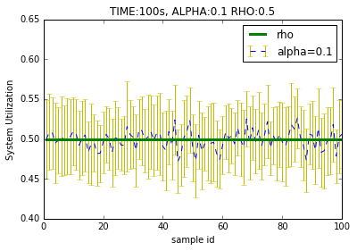

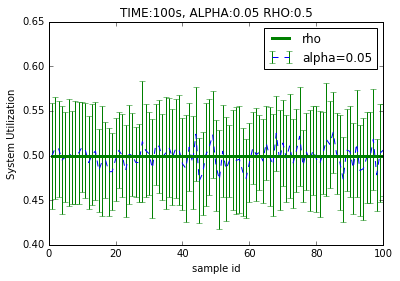

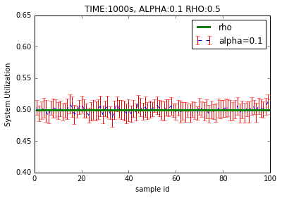

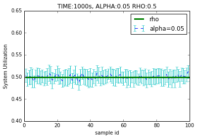

```python
part5_simstudy.task_5_2_4(0.5,0.1,100000,1)
part5_simstudy.task_5_2_4(0.5,0.05,100000,2)
part5_simstudy.task_5_2_4(0.5,0.1,1000000,3)
part5_simstudy.task_5_2_4(0.5,0.05,1000000,4)
```

For : Rho = 0.9, we obtained these plots.

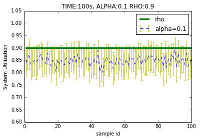

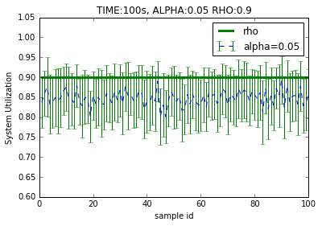

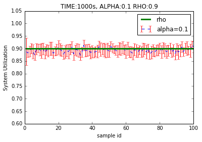

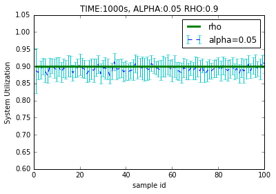

```python
part5_simstudy.task_5_2_4(0.9,0.1,100000,1)
part5_simstudy.task_5_2_4(0.9,0.05,100000,2)
part5_simstudy.task_5_2_4(0.9,0.1,1000000,3)
part5_simstudy.task_5_2_4(0.9,0.05,1000000,4)
```

- 5.3 Analysis and General Questions :
- Task 5.3.1: Confidence Interval Width :

In task 5.2.1, for the same simulation time we need more runs to reach the given width of the confidence interval if the confidence level is 95% campared to a confidence level of 90% which is normal since we are less confident for a confidence level of 90% that the true value is in our confidence interval so we need more runs to reach the given width of the confidence interval; otherwise we need more runs if the time simulation is 100s campared to 1000s because for a simulation of 1000s we are more confident that we can reach a steady state for the simulation. In task 5.2.2, for the same confidence level we need more simulation time to reach the given width of the confidence interval if the number of packets N of one batch is 1000 campared to the number N of 100 and this can be explained by the fact that the simulation time for N of 1000 packets is longer than a simulation for N of 100 packets.

Using the batches is superior to replication of the same simulation because each replication contains a startup segment which may not be representative of steady behavior of the simulation; on the other hand the advantage of using the batches is that a single run can be used to obtain an estimate and only one transient state is included in the output.

- Task 5.3.2: Confidence Interval Width :

The analytic formula yields : blocking probability = 0.126 but in the task 5.2.1 the calculated blocking probabilities always differ and that can be axplained by the fact that in the replication method each replication contains a transcient phase which affects the calculation of the blocking probability. But, in the task 5.2.2 it doesn't differ since only one transient state is included in the output. For example, we compute the mean of the blocking probability couter for 100s simulation time and alpha = 5% we find : blocking probability = 0.125087494665 which is roughly egal to the analytic value.

- Task 5.3.3: Confidence Interval Width :

- Task 5.3.4: Variable Simulation Time :

This simulation isn't an option because like this we are taking batches with different sizes and these batches are dependent ( so correlated ). On the other hand, in order to find the Steady-State we need samples which are indepedent and indentically distributed.